# Introduction à Python

01/10/2021

## Introduction à Python

Python est un **langage de haut niveau interprété** initialement publié en 1991. Il a progressivement pris le pas sur **Perl** en bioinformatique jusqu’à le dépasser fin des années 2010.

Depuis, les versions se sont succédées, Python est maintenant utilisé sur un grand nombre de plateformes et pour des applications **très diversifiées**.

C’est un langage **open-source**. avec une **importante** communauté de développeurs.

Dans le domaine de la bioinformatique, Python est plutôt utilisé dans le développement d’applications et de pipelines (exemple: transformations de fichiers).

## Charactéristiques

Python possède:

- Une syntaxe **claire et cohérente**
- Une indentation significative: **Ce sont les indentations qui structurent le code**.
- Une gestion **automatique de la mémoire** (*Garbage collector*)
- Un **Typage dynamique fort** sans déclaration explicite.
- On peut passer en développement orienté objet (pas obligatoire)
- Structure multi-fichiers des applications, ce qui facilite le développement et la maintenance.
- Un grand nombre de bibliothèques (**packages**) sont disponibles dans un grande variété de domaines.

## Monde de fonctionnement

Python peut être utilisé en **mode interactif**, ou comme un language interprété rapide.

- Les commandes peuvent être enregistrées dans un fichier **.py** appelé *script*. Python peut ensuite directement executer ce fichier (Il crée un *bytecode* intermédiaire)
- On peut utiliser un interpréteur (Exemple **idle**, fourni avec python) pour obtenir un résultat immédiat aux commandes (comme avec l’interpreteur **R**)

```python
Python 3.9.6 | packaged by conda-forge | (default, Jul 11 2021, 03:39:48)
[GCC 9.3.0] on linux
Type "help", "copyright", "credits" or "license" for more information.
>>> 2+3
5
>>> quit()
```

## Documentation

Documentation **Python 3** (Anglais): https://docs.python.org/3/

Le tutoriel Python (fr): https://docs.python.org/fr/3/tutorial/index.html

## Environnement de travail

On peut directement taper des instructions dans l’invite de commande. On peut aussi enregistrer une suite d’instructions (un programme) dans un fichier `.py`, de manière à les exécuter plusieurs fois.

Nous pouvons utiliser l’interpréteur python fourni avec **conda**.

Pour éditer nos programmes, il est possible d’utiliser **Gedit** fourni avec linux.

```bash
sudo apt-get install gedit
```

D’autres éditeurs existent, comme **Notepad++** sous Windows ou **TextMate** sous MacOS. **Geany** est un IDE également intéressant.

## Style de nommage

Durant ce cours, nous allons tenter de respecter les règles de nommage suivantes:

- `UPPERCASE` ou `UPPER_CASE` pour les *constantes*
- `TitleCase` pour les *classes*
- `UneExceptionError` pour les *exceptions*
- `camelCase` pour les *fonctions*, les *méthodes* et les *interfaces graphiques*
- `unmodule_m` pour les *modules*
- `lowercase` ou `lower_case` pour les *variables*

Enfin, on utilisera les notations suivantes pour faire des *réservations*

```python
 _xxx # usage interne
__xxx # attribut de classe
__xxx__ # nom spécial réservé
```

## Exemples

```python
MY_CONSTANT = 12        # UPPER_CASE
class MyClass: pass     # TitleCase
def myFunction(): pass  # camelCase
my_id = 5               # lower_case
```

## Mots clés

```python
and
as
assert
break
class
continue
def
del
from
eli
global
else
if
except
import
False
in
finally
is
raise
for
lambda
return
None
True
nonlocal
try
not
while
or
with
pass
yield
```

## Premier programme “Hello World!”

Stocker le texte suivant dans **helloworld.py**.

```python
#!/usr/bin/env python3

print("Hello World")
```

Puis

```bash
python helloworld.py
Hello World
```

## Variables en python

Elles sont initialisées à travers une **affectation** par l’utilisation du signe `=`.

```python
a = 2
type(a)
```

```
## <class 'int'>
```

```python
b = 5.0
type(b)
```

```
## <class 'float'>
```

```python
c = a*b
type(c)
```

```
## <class 'float'>
```

```python
d = 2/5
type(d)
```

```
## <class 'float'>
```

```python
print(d)
```

```
## 0.4
```

```python
e = 2//5
type(2//5)
```

```
## <class 'int'>
```

```python
print(e)
```

```
## 0
```

## Opérateurs arithmétiques

Addition, Soustraction, Multiplication, Division

```python
x + y
x - y
x * y
x / y
```

Division entière, Modulo

```python
x // y
x % y
```

Puissance

```python
x ** y
```

Valeur absolue

```python
abs(x)
```

Conversions Entier/Flottant

```python
float(x)
int(x)
```

Négation, Et, Ou , Ou exclusif

```python
-x
x & y
x | y
x ^ y
```

Décalages

```python
x >> y
x << y
```

## Type booléen

Les variables booléennes peuvent valoir soit **True** (Vrai) soit **False** (Faux). Les opérateurs booléens retournent une valeur booléeenne.

Neg, Et, ou

```python
not x
x or y
x and y
```

Comparaisons: Inférieur ou égal

```python
x < y   # strict
x <= y
```

Comparaisons: Supérieur ou égal

```python
x > y   # strict
x >= y
```

Comparaison: Egale ou différent

```python
x == y
x != y
```

## Type flottant

```python
2.718
```

```
## 2.718
```

```python
0.02
```

```
## 0.02
```

```python
3e8
```

```
## 300000000.0
```

```python
6.023e23
```

```
## 6.023e+23
```

```python
import math
math.sin(math.pi/4)
```

```
## 0.7071067811865475
```

```python
math.degrees(math.pi)
```

```
## 180.0
```

```python
math.factorial(9)
```

```
## 362880
```

```python
math.log(1024, 2)
```

```
## 10.0
```

## Type complexe

La partie imaginaire est suffixée par `j`

```python
1j
```

```
## 1j
```

```python
(2+3j) + (4-7j)
```

```
## (6-4j)
```

```python
(9+5j).real
```

```
## 9.0
```

```python
(9+5j).imag
```

```
## 5.0
```

```python
abs(3+4j)
```

```
## 5.0
```

```python
import cmath
cmath.phase(-1 + 0j)
```

```
## 3.141592653589793
```

```python
cmath.polar(3 + 4j)
```

```
## (5.0, 0.9272952180016122)
```

```python
cmath.rect(1., cmath.pi/4)
```

```
## (0.7071067811865476+0.7071067811865475j)
```

## Variables

Dès que l’on a une valeur correspondant à un type de données, il faut la stocker avec une variable. Comme nous l’avons vu, elles sont **affectées** grâce au signe égal `=`.

Attention, ce n’est **pas** le signe égal des mathématiques.

Dans une affectation, le membre de droite est affecté au membre de gauche.

En réalité, une variable est une **référence d’objet**. Cela correspond à une adresse mémoire dans l’ordinateur. Cette notion est importante dans le cas d’objets complexes, telles que les listes.

```python
a =2
b = math.log(2)
a = a - 1
print(a)
```

```
## 1
```

## Affectation vs Comparaison

Attention, **affecter** n’est *PAS* comparer.

C’est pour cela qu’il existe deux signes distincts:

- Affectation: Utilisation du signe `=`
- Comparaison: Utilisation du signe `==`

```python
x = 2
if(x==2):
  print(x)
```

```
## 2
```

## Variantes de l’affectation

Affectation augmentée

```python
v = 2
v += 4
```

Affectations multiples

```python
c = d = 8
```

Affectation parallèle

```python
e, f = 3.5, 2.6

g, h, i = ['A', 'B', 'C']

print(g)
```

```
## A
```

```python
print(h)
```

```
## B
```

Retour multiple d’une fonction

```python
(c,d) = ma_fonction()
```

## Chaines de caractères

C’est un type de données **Non modifiable**.

```python
print("Première forme avec un retour à la ligne à la fin\n")
```

```
## Première forme avec un retour à la ligne à la fin
```

```python
print(r"Deuxième forme sans retour à la ligne\n")
```

```
## Deuxième forme sans retour à la ligne\n
```

```python
print("""
Troisième forme multi-ligne
""")
```

```
##
## Troisième forme multi-ligne
```

```python
print('test "\n\n')
```

```
## test "
```

## Opérations sur les chaines de caractères

```python
s = "abcde"
len(s)
```

```
## 5
```

```python
s2 = "fgh"
print(s + s2)
```

```
## abcdefgh
```

```python
print(s * 4)
```

```
## abcdeabcdeabcdeabcde
```

## Extraction de caractères

n-ième caractère

```python
s[n]
```

n-ième caractère en partant de la fin

```python
s[-n]
```

Extraction de plusieurs caractères

```python
s[n:m] # intervalle n-m
s[:n]  # n premiers caractères
s[n:]  # derniers caractères en partant du n-ième
s[-n:] # n derniers caractères
```

## Chaines de caractères: fonctions *vs* méthodes

Une fonction est directement appelée par l’opérateur ():

```python
s = "abcde"
len(s)
```

```
## 5
```

Une méthode est appliquée à un objet en utilisant la **notation pointée** entre la variable et le nom de la méthode, suivi de l’opérateur ():

```python
s = "abcde"
s2 = s.upper()
print(s2)
```

```
## ABCDE
```

## Test sur chaines de caractères

- Pour tester le contenu d’une chaîne

```python
s.isupper() # Vrai si s ne contient que des majuscules
s.islower() # Vrai si s ne contient que des minuscules
s.istitle() # Vrai si seule la première lettre de chaque mot de s est une majuscule
s.isalnum() # Vrai sur s ne contient que des char alphanumériques ou des espaces
s.isalpha() # Vrai sur s ne contient que des char alphabétiques
s.isdigit() # Vrai si s ne contient que des caractères numériques
s.isspace() # Vrai si s ne contient que des espaces
s.startswith('ab') # Vrai si s commence par 'ab'
s.endswith('cd') # Vrai si s fini par 'ab'
```

## Transformations sur chaines de caractères

Transformation de casse

```python
s = "Dire Straits"
s.lower() # dire straits
s.upper() # DIRE STRAITS
s.capitalize() # Dire straits
s.swapcase() # dIRE sTRAITS
```

Ajustements

```python
expandtabs([nspaces]) # Remplace les tabulatioins avec nspaces espaces
center(width[, fillchar]) # Centre la chaine en remplissant avec fillchar
ljust(width[, fillchar]) # Justifie à gauche en emplissant avec fillchar
rjust(width[, fillchar]) # Justifie à droite en emplissant avec fillchar
zfill(width) # remplit à gauche avec des zéros pour obtenir une chaine de taille width
```

## Conversions de type

la **conversion de type** permet de passer d’un type à l’autre. En général, on se sert du nom du type avec des parethèses:

```python
bool(var)
int(var)
float(var)
str(var)
```

## Entrées-sorties

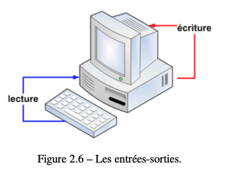

Les programmes ont besoin d’interagir avec les utilisateurs. Cela se fait au travers des **entrées-sorties**.

**Entrées:** Pour les entrées, cela peut se faire par une invite de commande qui permet à l’utilisateur de taper une chaîne de caractère (Fonction `input`).

**Sorties** Pour les sorties, cela peut se faire à travers l’impression d’un message à l’écran ou dans un fichier texte (Fonction `print`).

## Entrées-sorties

Fonction **Print**: Elle permet d’imprimer une chaîne de caractères à l’écran.

```python
print("Hello World")
```

```
## Hello World
```

```python
print("Hello World", 1, 3)
```

```
## Hello World 1 3
```

```python
print("Hello {:s}:  {:2d}, {:05d}".format('World', 1, 3))
```

```
## Hello World:   1, 00003
```

## Entrées-sorties

Fonction **Input**: permet de récupérer une chaîne de caractères tapée par l’utilisateur

```python
a = input("Entrez une valeur: ")
Entrez une valeur: 10
print(a)
10
```

## Séquences d’échappement

Il peut être nécessaire d’utiliser les séquences d’échappement pour imprimer des caractères dit **spéciaux**.

Par exemple, pour insérer une apostrophe dans une chaîne:

```python
ma_chaine = "Je suis d'accord"
```

## Contrôle de flux d’instruction

Il existe 3 concepts importants à utiliser lorsque l’on structure un programme Python:

- Les **Blocs**
- Les **Structures de contrôle**:
  - Les **Branchements**
  - Les **Boucles**

Dans la syntaxe python, ce qui suit un ‘#’ est un **commentaire**. Les **Blocs** sont alignés au **même niveau d’indentation**, et les structures de contrôle sont délimitées par **deux points ‘:’**.

## Les Blocs

Un Bloc d’instruction est une **unité de programmation** qui regroupe une séquence ordonnée d’instructions qui s’exécutent **les unes après les autres**.

Ces blocs sont branchés les uns aux autres à travers les **structures de contrôle**.

```python
# Commentaire
instruction(bloc1)
instruction(bloc1)
structure_de_controle:
  instruction(bloc2)
  instruction(bloc2)
```

Exemple:

```python
# Commentaire
i = 0
maxi =10
while (i < j):
  print("i est inférieur à maxi")
  i = i + 1
```

## Les branchements

Les **tests** permettent de choisir un chemin d’exécution en fonction de la valeur de certaines variables.

```python
if (condition1):
  instructions1
elif (copndition2):
  instructions2
else:
  instructions3
```

Exemple:

```python
if (i < 5):
  print("i est inférieur à 5")
elif (i == 5):
  print("i est égal à 5")
else:
  print("i est supérieur à 5")
```

## Les boucles for

`for` est un itérateur sur une collection d’objet. Il permet de parcourir les éléments de la collection.

```python
for variable in collection:
  instructions
```

Exemples:

```python
for i in range(5):
  print("i=", i)
```

```
## i= 0
## i= 1
## i= 2
## i= 3
## i= 4
```

```python
for ch in "Hello":
  print("ch=", ch)
```

```
## ch= H
## ch= e
## ch= l
## ch= l
## ch= o
```

## Les boucles while

Les boucles `while` permettent d’exécuter un bloc tant qu’un test est vrai. Il ne s’agit pas d’explorer l’intégralité des itérations mais de cherche quelque chose ou de faire une boucle infinie.

```python
while (test):
  instructions
```

Exemple:

```python
i = 0
while (i < 5):
  print("i est inférieur à 5")
  i = i + 1
```

## Instructions de contrôle

Les mots clés suivants sont utilisables dans les boucles `for` et `while`:

- `break` permet de **sortir de la boucle la plus interne** où l’on se situe
- `continue` permet de passer directement au tour de la boucle suivants sans executer les instructions
- `else` permet de rajouter des instructions qui seront exécutées si aucun break n’a été déclenché.

## les conteneurs standard

En python, les **conteneurs** standards sont

- Les **listes**
- Les **tuples**
- Les **ensembles** (sets)
- Les **dictionnaires**

## Les tuples

Les tuples permettent de regrouper des **éléments de différentes nature** en une seule structure. Ils ne sont **pas modifiables**. Il sont notés avec des parenthèses et des virgules pour séparer les éléments:

```python
mon_tuple = ( 1, 2, 'abc')
```

Les opérateurs des tuples permettent la concaténation, la filtration ou l’extraction d’éléments, et sont très similaires à ceux des chaînes de caractères

```python
len(t)     # nombre d'éléments dans le tuple
t1 + t2    # Concaténation de ’t1’ et ’t2’
t * n      # Répétition ’n’ fois du tuple ’t’
t[n]       # Extraction du n-ième élément du tuple en partant de la gauche
t[-n]      # Extraction du n-ième élément du tuple en partant de la droite
t[:n]      # Extraction des ’n’ premiers éléments du tuple
t[n:]      # Extraction des éléments ’n’ à la fin du tuple
t[-n:]     # Extraction des ’n’ derniers éléments du tuple
t[n:m]     # Extraction des éléments qui sont entre ’n’ et ’m’
```

## Les listes

Les listes servent à stocker des **collections ordonnées d’éléments** avec possibilité de les étendes ou de les manipuler facilement. On les note avec des crochets:

```python
l = [6, 8, 24, 12 ]
```

Les opérateurs des listes permettent la concaténation, la filtration ou l’extraction d’éléments, et sont très similaires à ceux des chaînes de caractères.

```python
len(l)       # Nombre d’éléments dans la liste
del(l[n])    # Détruit l’élément ’n’ de la liste ’l’
l.clear()    # Vide la liste ’l’
l.copy()     # Renvoie une copie de la liste ’l’
l.append(e)  # Ajoute l’élément ’e’ à la fin de la liste ’l’
l.insert(n, e) # Insère l’élément ’e’ à la position’n’ dans la liste ’l’
l1 + l2     # Concaténation de ’l1’ et ’l2’
l * n       # Répétition ’n’ fois de la liste ’l’
l[n]        # Extraction du n-ième élément en partant du début de la liste
l[-n]       # Extraction du n-ième élément en partant de la fin de la liste
l[:n]       # Extraction des ’n’ premiers éléments de la liste
l[n:]       # Extraction des éléments ’n’ à la fin de la liste
l[-n:]      # Extraction des ’n’ derniers éléments de la liste
l[n:m]      # Extraction des éléments qui sont entre ’n’ et ’m’
```

## Les ensembles

Les ensembles sont des listes **non ordonnées d’éléments uniques** (*set* en anglais), ils sont **extensibles** et ne gardent aucune notion d’ordre entre les éléments qu’ils contiennent. On les note avec des accolades:

```python
s = { 'python', 'C++', 'javascript' }
```

Les opérations que l’on peut faire incluent les opérations mathématiques de type ensembliste:

```python
len(s)       # Taille de l’ensemble ’s’
s.add(e)     # Ajoute ’e’ à ’s’
s.remove(e)  # Retire ’e’ de ’s’ (erreur si ’e’ ̸∈ ’s’)
s.discard(e) # Retire ’e’ de ’s’
s.clear()    # Vide l’ensemble ’s’
s1 | s2      # Union de ’s1’ et ’s2’
s1 & s2      # Intersection de ’s1’ et ’s2’
s1 - s2      # Différence de ’s1’ et ’s2’
s1 ^ s2      # Différence exclusive de ’s1’ et ’s2’
```

## Les ensembles (suite)

Les opérations que l’on peut faire incluent les opérations mathématiques de type ensembliste: (suite)

```python
e in s        # ’e’ ∈ ’s’
e not in s    # ’e’ ̸∈ ’s’
s1 == s2      # ’s1’ égal ’s2’
s1 != s2      # ’s1’ différent de ’s2’
s1 < s2       # ’s1’ est inclus (strict) dans ’s2’
s1 <= s2      # ’s1’ est inclus ou égal à ’s2’
s1 > s2       # ’s2’ inclus (strict) dans ’s1’
s1>=s2        # ’s2’ inclus ou égal à ’s1’
s1.isdisjoint(s2)  # ’s1’ disjoint de ’s2’
s1.issubset(s2)    # ’s1’ inclus dans ’s2’
s1.issuperset(s2)  #  ’s1’ inclus ’s2’
```

## Les dictionnaires (ou tableaux associatifs)

Les dictionnaires sont des **ensembles associatifs** associant une **clé** en entrée avec une **valeur**. Les dictionnaires sont encadrés par des accolades et chaque couple ’clef:valeur’ est séparé par une virgule:

```python
mon_dict = {  'mardi': 2, 'dimanche':7 }
```

Et on accède à la valeur comme suit: `mon_dict['mardi']`.

Les opérateur permettent de faire des recherche, d’ajouter et modifier des entrées:

```python
len(d)     # Nombre d’éléments du dictionnaire
del(d[k])  #  Détruit l’entrée ’k’ du dictionnaire
d.clear()  # Vide le dictionnaire ’d’
d.copy()   # Renvoie une copie du dictionnaire ’d’
d[k]       # Accède à la valeur de la clef ’k’
d[k] = v   # Assigne la valeur ’v’ à la clef ’k’
k in d     # Teste si la clef ’k’ est présente dans le dictionnaire ’d’
k not in d # Teste si la clef ’k’ n’est pas présente dans le dictionnaire ’d’
```

## Les fichiers: ouverture/fermeture

Python utilise par défaut les fichiers texte. Ils peuvent être ouverts avec la fonction `open` suivant plusieurs modes:

- En **lecture**

```python
 fd = open("monFichier.txt", "r", encoding=’utf-8’)
```

- En **écriture**

```python
 fd = open("monFichier.txt", "w", encoding=’utf-8’)
```

- En **ajout**

```python
 fd = open("monFichier.txt", "a", encoding=’utf-8’)
```

Il faut ensuite **fermer** le fichier. Tant qu’il n’est pas fermé, son contenu n’est **pas garanti sur disque**.

```python
fd.close()
```

## Les fichiers: lecture

Lecture total ou partielle

```python
f = open("monfichier.txt", "r")
s = f.read() # lit tout le fichier --> string
s = f.read(3) # lit au plus n octets --> string
s = f.readline() # lit la ligne suivante --> string
s = f.readlines() # lit tout le fichier --> liste de strings
f.close()
```

Lecture ligne à ligne:

```python
f = open("monfichier.txt") # mode "r" par défaut

for ligne in f:
  print(ligne[:-1]) # pour sauter le retour à la ligne
f.close()
```

## Ecriture dans un fichier

On écrit dans un fichier avec la fonction `write`. Voici un exemple d’écriture séquentielle:

```python
f = open("monfichier.txt", "w") # mode "w"

s = '# fichier contenant 3 lettes de l\'alphabet'
f.write(s)

ma_liste = ['a', 'b', 'c']
for l in ma_liste:
  f.write(l)
f.close()
```

Alternativement:

```python
ma_liste = ['a', 'b', 'c']
f.writelines(l)
```

## Affichage formaté (format)

**Objectif**: formatage d’objet pour leur affichage avec la fonction `format`.

```python
my_float = 1.787656345e-2
print("{:f}".format(my_float))   # Défaut
print("{:.4f}".format(my_float)) # précision de 4 chiffres après la virgule
print("{:e}".format(my_float))   # Mode exposant
print("{:.7e}".format(my_float)) # précision de 7 chiffres après la virgule
print("{:.2%}".format(my_float)) # en pourcentage


my_int = 42
print("{:d}".format(my_int))    # Entier
print("{:5d}".format(my_int))   # Entier sur 5 caractères
print("{:05d}".format(my_int))  # Entier  sur 5 caractères remplis avec des zéros

my_str = "Linux"
print("{:d} {:s}".format(my_int, my_str)) # Chaine de caractères

coord = {'latitude': '37.24N', 'longitude': '-115.81W'}
print('Coordinates: {latitude}, {longitude}'.format(**coord))
```

## Les fonctions

Les **fonctions** permettent de rendre un programme modulaire en évitant de réécrire plusieurs fois le même code. Elle est définie par son **prototype** comportant le mot-clé `def`, son **nom**, ses **arguments** et aussi son **type de retour**.

```python
# Défninition d'une fonction
def ma_fonc(args):
  instructions
  return(x)

# Programme principal
instructions
x = ma_fonc(args)
instructions
```

```python
# Défninition d'une fonction
def multi(a, b):
  res = a * b
  return(res)

# Programme principal
a = 2; b = 4
res_multi = multi(a, b)
print(res_multi)
```

Les **arguments** sont les variables passées à la foinction. Ils ne sont pas **typés** *a priori* mais substitués dynamiquement dans le code lors de l’execution. Du coup, il est possible **d’appliquer la fonction à différents type** sans **avoir à la réécrire**.

Le **type de retour** correspond à **ce que retourne la fonction**. Le mot clé `return` permet de définir la fin de la fonction et de définir ce qui est retourné. On peut retourner **plusieurs** variables en Python, ou `None`.

## Passage par valeur

Dans la plupart des langages, il existe deux modes de passage des arguments. Lors du passage des arguments **par valeur**, seule **une copie des valeurs** sont utilisées, mais pas les variables originales. Les changements effectués sur les arguments sont locaux à la fonction et le seul moyen de récupérer les changements est de passer par l’instruction `return`.

Exemple de passage d’argument par valeur:

```python
def affi(s):
  s = "Je suis dans la fonction !"
  print (s)

s = "Je suis dans le main !"
affi(s)
```

```
## Je suis dans la fonction !
```

```python
print(s)
```

```
## Je suis dans le main !
```

```python
def affi(s):
  s = "Je suis dans la fonction !"
  print (s)
  return s
s = "Je suis dans le main !"
s= affi(s)
```

```
## Je suis dans la fonction !
```

```python
print(s)
```

```
## Je suis dans la fonction !
```

## Passage par référence

Dans la plupart des langages, il existe deux modes de passage des arguments. Lors du passage des arguments **par valeur**, seule **une copie des valeurs** sont utilisées, mais pas les variables originales. Les changements effectués sur les arguments sont locaux à la fonction et le seul moyen de récupérer les changements est de passer par l’instruction `return`.

Exemple de passage d’argument par référence:

Contrairement à l’exemple précédent, d est modifié même sans la présence du `return`.

```python
def modif(d):
  d['cle'] = "Je suis dans la fonction !"
  # pas de return

d = { 'cle': "Je suis dans le main !", }

modif(d)
print(d)
```

```
## {'cle': 'Je suis dans la fonction !'}
```

## Variables locales/globales

La **portée d’une variable** (*variable scope*) correspond aux zone du programmes dans lesquelles cette variable peut être appelée.

Une variable est dite **globale** si sa portée recouvre l’ensemble du programme. Une variable est dite **locale** si sa portée est limitée à une partie du programme, par exemple à une **fonction**.

```python
def affi():

  s = "Je suis dans la fonction !"
  print (s)

s = "Je suis dans le main !"
affi()
```

```
## Je suis dans la fonction !
```

```python
print(s)
```

```
## Je suis dans le main !
```

```python
def affi():
  global s
  s = "Je suis dans la fonction !"
  print (s)

s = "Je suis dans le main !"
affi()
```

```
## Je suis dans la fonction !
```

```python
print(s)
```

```
## Je suis dans la fonction !
```

## Documenter ses fonction

Les **docstrings** sont des chaînes de caractères qui suivent immédiatement le `def` et qui constituent la documentation de la fonction en question. Cette documentation permet de **comprendre ce que fait la fonction** et **d’aider à l’utiliser correctement**.

```python
def multi(a, b):
  """This function multiplies its two arguments.
  Exemple: res = multi(10,11)."""
  res = a * b
  return(res)
help(multi)
```

```
## Help on function multi in module __main__:
##
## multi(a, b)
##     This function multiplies its two arguments.
##     Exemple: res = multi(10,11).
```

## Utilitaires: enumerate et zip

Les fonctions enumerate() et zip() sont utiles pour les itérations sur des structures.

- `enumerate`: Associe un index sur une structure lorsqu’il n’y en a pas
- `zip`: Permet d’itérer deux structures en parallèle, même de tailles différentes

```python
my_set = { 'a', 'b', 'c', 'd'}

for index, item in enumerate(my_set):

  print(index, item)
```

```
## 0 b
## 1 c
## 2 d
## 3 a
```

```python
mylist1 = [5, 3, 9, 4]
mylist2 = ['a', 'w', 'd']
for index, char in zip(mylist1, mylist2):
  print (index , char)
```

```
## 5 a
## 3 w
## 9 d
```

## Références

- Bob Cordeau *Introduction à Python 3* (Ouvrage): Une introduction à Python 3
- Emmanuel Fleury. *Introduction à la programmation Python* (Diapositives): https://www.labri.fr/perso/fleury/documents/initiation-python3-slides.pdf

## Licence

Cette œuvre est mise à disposition selon les termes de la [Licence Creative Commons:](http://creativecommons.org/licenses/by-nc-nd/4.0/)  
Attribution - Pas d’Utilisation Commerciale - Pas de Modification 4.0 International (CC BY-NC-ND 4.0).